# Case Study: How Can a Wellness Technology Company Play It Smart?

Mauricio Emilio Monroy González

December 18, 2024

### Contents

1. Summary
2. Ask Phase: Business task
3. Prepare Phase: Data Sources
4. Process Phase: Data Manipulation Documentation  
   4.1 Library and dataframe import  
   4.2 Cleaning
5. Analyze and Share Phase  
   5.1 Trending Measurement Features  
   5.2 User Demographics and Patterns  
   5.3 Correlation Between Variables  
   5.4 Consistency in Use of Smart-Device
6. Act Phase
7. References

# Summary

Based on data, Bellabeat can have a major leap in the health monitoring industry by innovating in smart-device tracking, taking advantage of trends, and exploiting potential opportunities with users and technology alike. In this report, data was extracted from a FitBit user log spanning two months of recordings from over 30 users across different categories. From there, in RStudio, data cleaning was carried out across multiple data frames, analysis conducted, and visualizations drawn, all so that Bellabeat could have solidly-based recommendations as to what to do in order to accomplish its business task.

# Ask Phase

*Business Task*

- The global wearable technology market in health and fitness was projected to reach $60 billion USD by 2023 (Psico-Smart Editorial Team. 2024)
- Almost 1 in 3 Americans use a wearable device to track their health and fitness (NIH, 2023)
- In 2023, 75% of healthcare providers considered that patients using wearables displayed a better engagement with their fitness goals (Psico-Smart Editorial Team. 2024)

# Prepare Phase

*Data Sources Description*

To carry out the analysis required to help Bellabeat with their growth-oriented business task, the “FitBit Fitness Tracker Data” were used.

[output not shown]

# Process Phase

*Data Manipulation Documentation*

## Library and dataframe import

The libraries used throughout this process were the tidyverse, lubridate, janitor, skimr, dplyr.

```r
# Libraries loaded
library(tidyverse)
library(lubridate)
library(janitor)
```

```r
library(skimr)
library(tidyr)
library(dplyr)
library(ggplot2)
library(knitr)
# Path set
opts_knit$set(root.dir = "C:/Users/mauri/OneDrive/Documents/Personal/GoogleDataAnalytics/Bellabeat Case Study")
```

The dataset files will also be imported into dataframes. The datasets corresponding to the first month will have a trailing “1”,and the corresponding to the latter a trailing “2”, which will afterwards be merged into a single dataframe. Only the categories with the full pair will be used, so as to have as much data as possible and not fall into sampling bias errors. Also, if a category has pairs complete across different time measurements, the ones with the most measurements will be used in order to not get lost in details. That being said, the ones used will be:

- Daily Activity

```r
daiAct_1 <- read.csv("archive/merged/dailyActivity_merged.csv")
daiAct_2 <- read.csv("archive/merged/dailyActivity_merged2.csv")
dailyActivity <- rbind(daiAct_1, daiAct_2)
skim_without_charts(dailyActivity)
```

Data summary

| Name | dailyActivity |
| --- | --- |
| Number of rows | 1397 |
| Number of columns | 15 |
| _______________________ |  |
| Column type frequency: |  |
| character | 1 |
| numeric | 14 |
| ________________________ |  |
| Group variables | None |

**Variable type: character**

| skim_variable | n_missing | complete_rate | min | max | empty | n_unique | whitespace |
| --- | --- | --- | --- | --- | --- | --- | --- |
| ActivityDate | 0 | 1 | 8 | 9 | 0 | 62 | 0 |

**Variable type: numeric**

| skim_variable | n_missing | complete_rate | mean | sd | p0 | p25 | p50 | p75 | p100 |
| --- | --- | --- | --- | --- | --- | --- | --- | --- | --- |
| Id | 0 | 1 | 4.78121e+09 | 2.384293e+09 | 1503960366 | 2.320127e+09 | 4.445115e+09 | 6.962181e+09 | 8.877689e+09 |
| TotalSteps | 0 | 1 | 7.28090e+03 | 5.214340e+03 | 0 | 3.146000e+03 | 6.999000e+03 | 1.054400e+04 | 3.601900e+04 |
| TotalDistance | 0 | 1 | 5.22000e+00 | 3.990000e+00 | 0 | 2.170000e+00 | 4.950000e+00 | 7.500000e+00 | 2.803000e+01 |
| TrackerDistance | 0 | 1 | 5.19000e+00 | 3.980000e+00 | 0 | 2.160000e+00 | 4.950000e+00 | 7.480000e+00 | 2.803000e+01 |
| LoggedActivitiesDistance | 0 | 1 | 1.30000e-01 | 7.000000e-01 | 0 | 0.000000e+00 | 0.000000e+00 | 0.000000e+00 | 6.730000e+00 |
| VeryActiveDistance | 0 | 1 | 1.40000e+00 | 2.610000e+00 | 0 | 0.000000e+00 | 1.000000e-01 | 1.830000e+00 | 2.192000e+01 |
| ModeratelyActiveDistance | 0 | 1 | 5.40000e-01 | 8.700000e-01 | 0 | 0.000000e+00 | 2.000000e-01 | 7.700000e-01 | 6.480000e+00 |
| LightActiveDistance | 0 | 1 | 3.19000e+00 | 2.120000e+00 | 0 | 1.610000e+00 | 3.240000e+00 | 4.690000e+00 | 1.251000e+01 |
| SedentaryActiveDistance | 0 | 1 | 0.00000e+00 | 1.000000e-02 | 0 | 0.000000e+00 | 0.000000e+00 | 0.000000e+00 | 1.100000e-01 |
| VeryActiveMinutes | 0 | 1 | 1.96800e+01 | 3.168000e+01 | 0 | 0.000000e+00 | 2.000000e+00 | 3.000000e+01 | 2.100000e+02 |
| FairlyActiveMinutes | 0 | 1 | 1.34000e+01 | 2.640000e+01 | 0 | 0.000000e+00 | 6.000000e+00 | 1.800000e+01 | 6.600000e+02 |
| LightlyActiveMinutes | 0 | 1 | 1.85370e+02 | 1.140600e+02 | 0 | 1.110000e+02 | 1.950000e+02 | 2.620000e+02 | 7.200000e+02 |
| SedentaryMinutes | 0 | 1 | 9.92540e+02 | 3.133000e+02 | 0 | 7.290000e+02 | 1.057000e+03 | 1.244000e+03 | 1.440000e+03 |
| Calories | 0 | 1 | 2.26627e+03 | 7.530100e+02 | 0 | 1.799000e+03 | 2.114000e+03 | 2.770000e+03 | 4.900000e+03 |

- Heart Rate by Seconds

```r
heartR_1 <- read.csv("archive/merged/heartrate_seconds_merged.csv")
heartR_2 <- read.csv("archive/merged/heartrate_seconds_merged2.csv")
heartRate <- rbind(heartR_1, heartR_2)
skim_without_charts(heartRate)
```

Data summary

| Name | heartRate |
| --- | --- |
| Number of rows | 3638339 |
| Number of columns | 3 |
| _______________________ |  |
| Column type frequency: |  |
| character | 1 |
| numeric | 2 |
| ________________________ |  |
| Group variables | None |

**Variable type: character**

| skim_variable | n_missing | complete_rate | min | max | empty | n_unique | whitespace |
| --- | --- | --- | --- | --- | --- | --- | --- |
| Time | 0 | 1 | 19 | 21 | 0 | 1456216 | 0 |

**Variable type: numeric**

| skim_variable | n_missing | complete_rate | mean | sd | p0 | p25 | p50 | p75 | p100 |
| --- | --- | --- | --- | --- | --- | --- | --- | --- | --- |
| Id | 0 | 1 | 5462464830.4 | 1.978491e+09 | 2022484408 | 4020332650 | 5553957443 | 6962181067 | 8877689391 |
| Value | 0 | 1 | 78.1 | 1.923000e+01 | 36 | 64 | 74 | 88 | 203 |

- Hourly Calories

```r
hourCal_1 <- read.csv("archive/merged/hourlyCalories_merged.csv")
hourCal_2 <- read.csv("archive/merged/hourlyCalories_merged2.csv")
hourlyCalories <- rbind(hourCal_1, hourCal_2)
skim_without_charts(hourlyCalories)
```

Data summary

| Name | hourlyCalories |
| --- | --- |
| Number of rows | 46183 |
| Number of columns | 3 |
| _______________________ |  |
| Column type frequency: |  |
| character | 1 |
| numeric | 2 |
| ________________________ |  |
| Group variables | None |

**Variable type: character**

| skim_variable | n_missing | complete_rate | min | max | empty | n_unique | whitespace |
| --- | --- | --- | --- | --- | --- | --- | --- |
| ActivityHour | 0 | 1 | 19 | 21 | 0 | 1480 | 0 |

**Variable type: numeric**

| skim_variable | n_missing | complete_rate | mean | sd | p0 | p25 | p50 | p75 | p100 |
| --- | --- | --- | --- | --- | --- | --- | --- | --- | --- |
| Id | 0 | 1 | 4.869715e+09 | 2.422074e+09 | 1503960366 | 2320127002 | 4558609924 | 6962181067 | 8877689391 |
| Calories | 0 | 1 | 9.576000e+01 | 6.004000e+01 | 42 | 62 | 80 | 106 | 948 |

- Hourly Intensities

```r
hourInt_1 <- read.csv("archive/merged/hourlyIntensities_merged.csv")
hourInt_2 <- read.csv("archive/merged/hourlyIntensities_merged2.csv")
hourlyIntensities <- rbind(hourInt_1, hourInt_2)
skim_without_charts(hourlyIntensities)
```

Data summary

| Name | hourlyIntensities |
| --- | --- |
| Number of rows | 46183 |
| Number of columns | 4 |
| _______________________ |  |
| Column type frequency: |  |
| character | 1 |
| numeric | 3 |
| ________________________ |  |
| Group variables | None |

**Variable type: character**

| skim_variable | n_missing | complete_rate | min | max | empty | n_unique | whitespace |
| --- | --- | --- | --- | --- | --- | --- | --- |
| ActivityHour | 0 | 1 | 19 | 21 | 0 | 1480 | 0 |

**Variable type: numeric**

| skim_variable | n_missing | complete_rate | mean | sd | p0 | p25 | p50 | p75 | p100 |
| --- | --- | --- | --- | --- | --- | --- | --- | --- | --- |
| Id | 0 | 1 | 4.869715e+09 | 2.422074e+09 | 1503960366 | 2320127002 | 4.55861e+09 | 6.962181e+09 | 8877689391 |
| TotalIntensity | 0 | 1 | 1.140000e+01 | 2.072000e+01 | 0 | 0 | 2.00000e+00 | 1.500000e+01 | 180 |
| AverageIntensity | 0 | 1 | 1.900000e-01 | 3.500000e-01 | 0 | 0 | 3.00000e-02 | 2.500000e-01 | 3 |

- Hourly Steps

```r
hourSteps_1 <- read.csv("archive/merged/hourlySteps_merged.csv")
hourSteps_2 <- read.csv("archive/merged/hourlySteps_merged2.csv")
hourlySteps <- rbind(hourSteps_1, hourSteps_2)
skim_without_charts(hourlySteps)
```

Data summary

| Name | hourlySteps |
| --- | --- |
| Number of rows | 46183 |
| Number of columns | 3 |
| _______________________ |  |
| Column type frequency: |  |
| character | 1 |
| numeric | 2 |
| ________________________ |  |
| Group variables | None |

**Variable type: character**

| skim_variable | n_missing | complete_rate | min | max | empty | n_unique | whitespace |
| --- | --- | --- | --- | --- | --- | --- | --- |
| ActivityHour | 0 | 1 | 19 | 21 | 0 | 1480 | 0 |

**Variable type: numeric**

| skim_variable | n_missing | complete_rate | mean | sd | p0 | p25 | p50 | p75 | p100 |
| --- | --- | --- | --- | --- | --- | --- | --- | --- | --- |
| Id | 0 | 1 | 4.869715e+09 | 2.422074e+09 | 1503960366 | 2320127002 | 4558609924 | 6962181067 | 8877689391 |
| StepTotal | 0 | 1 | 3.024600e+02 | 6.774300e+02 | 0 | 0 | 20 | 322 | 10565 |

- METs (metabolic equivalents) by minute

```r
minMet_1 <- read.csv("archive/merged/minuteMETsNarrow_merged.csv")
minMet_2 <- read.csv("archive/merged/minuteMETsNarrow_merged2.csv")
minuteMET <- rbind(minMet_1, minMet_2)
skim_without_charts(minuteMET)
```

Data summary

| Name | minuteMET |
| --- | --- |
| Number of rows | 2770620 |
| Number of columns | 3 |
| _______________________ |  |
| Column type frequency: |  |
| character | 1 |
| numeric | 2 |
| ________________________ |  |
| Group variables | None |

**Variable type: character**

| skim_variable | n_missing | complete_rate | min | max | empty | n_unique | whitespace |
| --- | --- | --- | --- | --- | --- | --- | --- |
| ActivityMinute | 0 | 1 | 19 | 21 | 0 | 88800 | 0 |

**Variable type: numeric**

| skim_variable | n_missing | complete_rate | mean | sd | p0 | p25 | p50 | p75 | p100 |
| --- | --- | --- | --- | --- | --- | --- | --- | --- | --- |
| Id | 0 | 1 | 4.869556e+09 | 2.421986e+09 | 1503960366 | 2320127002 | 4558609924 | 6962181067 | 8877689391 |
| METs | 0 | 1 | 1.445000e+01 | 1.179000e+01 | 0 | 10 | 10 | 11 | 189 |

- Sleep by minute

```r
minSleep_1 <- read.csv("archive/merged/minuteSleep_merged.csv")
minSleep_2 <- read.csv("archive/merged/minuteSleep_merged2.csv")
minuteSleep <- rbind(minSleep_1, minSleep_2)
skim_without_charts(minuteSleep)
```

Data summary

| Name | minuteSleep |
| --- | --- |
| Number of rows | 387080 |
| Number of columns | 4 |
| _______________________ |  |
| Column type frequency: |  |
| character | 1 |
| numeric | 3 |
| ________________________ |  |
| Group variables | None |

**Variable type: character**

| skim_variable | n_missing | complete_rate | min | max | empty | n_unique | whitespace |
| --- | --- | --- | --- | --- | --- | --- | --- |
| date | 0 | 1 | 19 | 21 | 0 | 103063 | 0 |

**Variable type: numeric**

| skim_variable | n_missing | complete_rate | mean | sd | p0 | p25 | p50 | p75 | p100 |
| --- | --- | --- | --- | --- | --- | --- | --- | --- | --- |
| Id | 0 | 1 | 4.908215e+09 | 2.124247e+09 | 1503960366 | 3977333714 | 4702921684 | 6775888955 | 8792009665 |
| value | 0 | 1 | 1.090000e+00 | 3.200000e-01 | 1 | 1 | 1 | 1 | 3 |
| logId | 0 | 1 | 1.136556e+10 | 1.473333e+08 | 11103653021 | 11242403378 | 11366922636 | 11496429833 | 11616251768 |

- Weight Log information

```r
weightLog_1 <- read.csv("archive/merged/weightLogInfo_merged.csv")
weightLog_2 <- read.csv("archive/merged/weightLogInfo_merged2.csv")
weightLog <- rbind(weightLog_1, weightLog_2)
skim_without_charts(weightLog)
```

Data summary

| Name | weightLog |
| --- | --- |
| Number of rows | 100 |
| Number of columns | 8 |
| _______________________ |  |
| Column type frequency: |  |
| character | 2 |
| numeric | 6 |
| ________________________ |  |
| Group variables | None |

**Variable type: character**

| skim_variable | n_missing | complete_rate | min | max | empty | n_unique | whitespace |
| --- | --- | --- | --- | --- | --- | --- | --- |
| Date | 0 | 1 | 19 | 21 | 0 | 78 | 0 |
| IsManualReport | 0 | 1 | 4 | 5 | 0 | 2 | 0 |

**Variable type: numeric**

| skim_variable | n_missing | complete_rate | mean | sd | p0 | p25 | p50 | p75 | p100 |
| --- | --- | --- | --- | --- | --- | --- | --- | --- | --- |
| Id | 0 | 1.00 | 6.833681e+09 | 2.078994e+09 | 1.503960e+09 | 6.962181e+09 | 6.962181e+09 | 8.877689e+09 | 8.877689e+09 |
| WeightKg | 0 | 1.00 | 7.250000e+01 | 1.477000e+01 | 5.260000e+01 | 6.150000e+01 | 6.250000e+01 | 8.530000e+01 | 1.335000e+02 |
| WeightPounds | 0 | 1.00 | 1.598400e+02 | 3.255000e+01 | 1.159600e+02 | 1.355800e+02 | 1.377900e+02 | 1.880500e+02 | 2.943200e+02 |
| Fat | 96 | 0.04 | 1.975000e+01 | 6.650000e+00 | 1.000000e+01 | 1.900000e+01 | 2.200000e+01 | 2.275000e+01 | 2.500000e+01 |
| BMI | 0 | 1.00 | 2.537000e+01 | 3.520000e+00 | 2.145000e+01 | 2.400000e+01 | 2.439000e+01 | 2.559000e+01 | 4.754000e+01 |
| LogId | 0 | 1.00 | 1.461174e+12 | 1.083068e+09 | 1.459382e+12 | 1.460182e+12 | 1.461079e+12 | 1.462147e+12 | 1.463098e+12 |

## Cleaning

```r
# Duplicate rows
print("Duplicate rows per Dataframe")
```

```
## [1] "Duplicate rows per Dataframe"
```

```r
sum(duplicated(dailyActivity))
```

```
## [1] 0
```

```r
sum(duplicated(heartRate))
```

```
## [1] 23424
```

```r
sum(duplicated(hourlyCalories))
```

```
## [1] 175
```

```r
sum(duplicated(hourlyIntensities))
```

```
## [1] 175
```

```r
sum(duplicated(hourlySteps))
```

```
## [1] 175
```

```r
sum(duplicated(minuteMET))
```

```
## [1] 10500
```

```r
sum(duplicated(minuteSleep))
```

```
## [1] 4300
```

```r
sum(duplicated(weightLog))
```

```
## [1] 2
```

```r
# Unique ID count
print("Unique IDs per Dataframe")
```

```
## [1] "Unique IDs per Dataframe"
```

```r
n_unique(dailyActivity$Id)
```

```
## [1] 35
```

```r
n_unique(heartRate$Id)
```

```
## [1] 15
```

```r
n_unique(hourlyCalories$Id)
```

```
## [1] 35
```

```r
n_unique(hourlyIntensities$Id)
```

```
## [1] 35
```

```r
n_unique(hourlySteps$Id)
```

```
## [1] 35
```

```r
n_unique(minuteMET$Id)
```

```
## [1] 35
```

```r
n_unique(minuteSleep$Id)
```

```
## [1] 25
```

```r
n_unique(weightLog$Id)
```

```
## [1] 13
```

Apparently, there were lots of duplicates (likely stemming from certain overlap in data during the merging between months). Also, not all user IDs provided the same categories. To clean the dataframes, column names were standardized into lowercase and underscores, duplicate rows were sought to be removed, as well as those with missing values. For added control, the entries were also sorted by date.

```r
dailyActivity <- dailyActivity %>%
  clean_names() %>%
  distinct() %>%
  drop_na() %>%
  arrange(activity_date)
heartRate <- heartRate %>%
  clean_names() %>%
  distinct() %>%
  drop_na() %>%
  arrange(time)
hourlyCalories <- hourlyCalories %>%
  clean_names() %>%
  distinct() %>%
  drop_na() %>%
  arrange(activity_hour)
hourlyIntensities <- hourlyIntensities %>%
  clean_names() %>%
  distinct() %>%
  drop_na() %>%
  arrange(activity_hour)
hourlySteps <- hourlySteps %>%
  clean_names() %>%
  distinct() %>%
  drop_na() %>%
  arrange(activity_hour)
minuteMET <- minuteMET %>%
  clean_names() %>%
  distinct() %>%
  drop_na() %>%
  arrange(activity_minute)
minuteSleep <- minuteSleep %>%
  clean_names() %>%
  distinct() %>%
  drop_na() %>%
  arrange(date)
weightLog <- weightLog %>%
  clean_names() %>%
  distinct() %>%
  drop_na() %>%
  arrange(date)
```

Having almost finished cleaning the dataframes, to set a date format using the *lubridate* package, the following script was ran:

```r
dailyActivity <- dailyActivity %>%
  mutate(activity_date = mdy(activity_date))
heartRate <- heartRate %>%
  mutate(time = mdy_hms(time))
hourlyCalories <- hourlyCalories %>%
  mutate(activity_hour = mdy_hms(activity_hour))
hourlyIntensities <- hourlyIntensities %>%
  mutate(activity_hour = mdy_hms(activity_hour))
hourlySteps <- hourlySteps %>%
  mutate(activity_hour = mdy_hms(activity_hour))
minuteMET <- minuteMET %>%
  mutate(activity_minute = mdy_hms(activity_minute))
minuteSleep <- minuteSleep %>%
  mutate(date = mdy_hms(date))
weightLog <- weightLog %>%
  mutate(date = mdy_hms(date))
```

# Analyze and Share Phase

## Trending Measurement Features

For starters, following on the previous noteworthy mention of an unequal ID distribution among dataframes, an informed inference could be conducted about user interest on particular metrics, and how they use their FitBit equipment. Therefore, seeking to find the number of distinct IDs per dataframe, for starters>

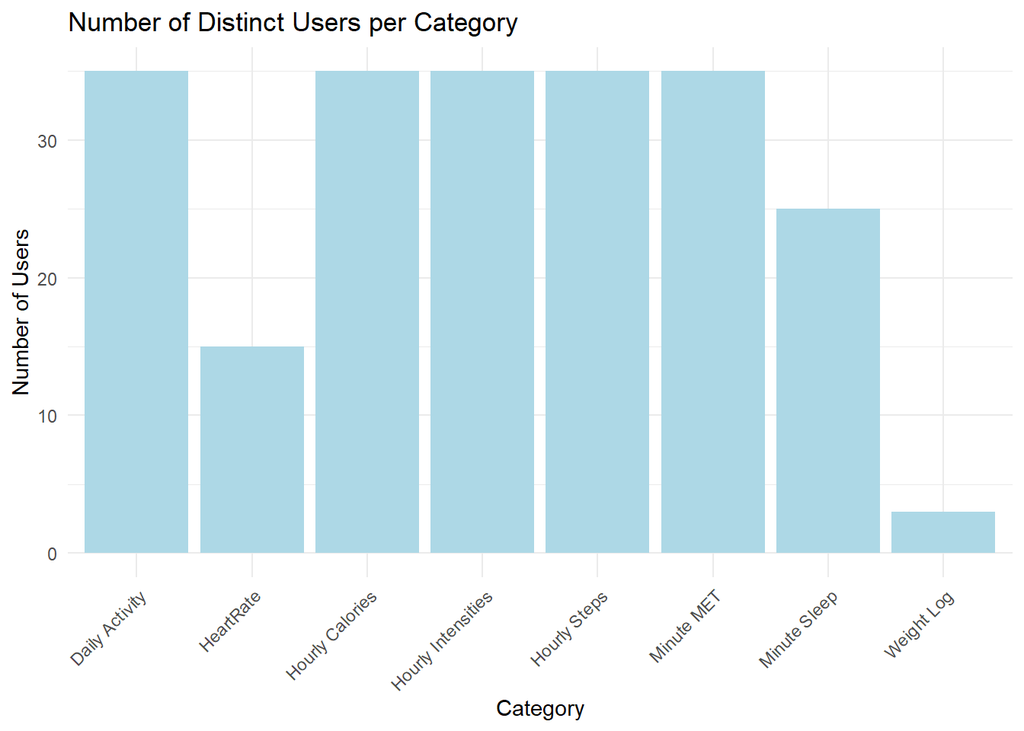

```r
usersDailyActivity <- n_distinct(dailyActivity$id)
usersHeartRate <- n_distinct(heartRate$id)
usersHourlyCalories <- n_distinct(hourlyCalories$id)
usersHourlyIntensities <- n_distinct(hourlyIntensities$id)
usersHourlySteps <- n_distinct(hourlySteps$id)
usersMinuteMET <- n_distinct(minuteMET$id)
usersMinuteSleep <- n_distinct(minuteSleep$id)
usersWeightLog <- n_distinct(weightLog$id)
distinctUsers <- data.frame(category = c("Daily Activity", "HeartRate", "Hourly Calories", "Hourly Intensities", "Hourly Steps", "Minute MET", "Minute Sleep", "Weight Log"), users = c(usersDailyActivity, usersHeartRate, usersHourlyCalories, usersHourlyIntensities, usersHourlySteps, usersMinuteMET, usersMinuteSleep, usersWeightLog))
ggplot(distinctUsers, aes(x = category, y = users)) + geom_bar(stat = "identity", fill = "lightblue") + labs(title = "Number of Distinct Users per Category", x = "Category", y = "Number of Users") + theme_minimal() + theme(axis.text.x = element_text(angle = 45, hjust = 1))
```

Apparently, not all users are really concerned with their Heart Rate, Sleeping Trends and even less with their Weight Logs. For Bellabeat, this is both a pro and con, having a market segment that could grow, but currently does not have enought attention from consumers. As such, the trend appears fixated on consumers’ interest in their Activity Monitoring, not on their health overall.

## User Demographics and Patterns

Having identified user interest in lifestyle and activity, the question can be asked, “who are these users?”, and what do their day-to-day activities consist on?. Not much information is given due to privacy reasons, so a different approach was taken. To define 5 baselines over which to group users based on step count, the maximum amount of steps was found using:

```r
maxSteps <- max(dailyActivity$total_steps)
set <- maxSteps / 5
```

Five categories will be defined:

- Sedentary: 0-7203 steps
- Sedentary-Active: 7203-14406 steps
- Active: 14406-21609 steps
- Active-Athletic: 21609-28812 steps
- Athletic: +28812 steps

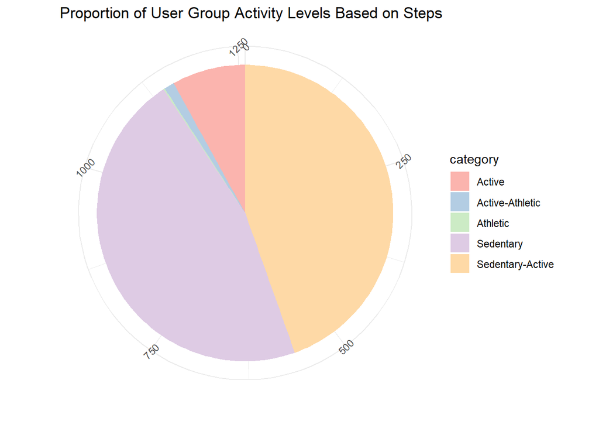

```r
setAthletic <- dailyActivity %>%
  filter(total_steps > 28812) %>%
  summarise(count = n())
setActiveAthletic <- dailyActivity %>%
  filter(21609 < total_steps & total_steps < 28812) %>%
  summarise(count = n())
setActive <- dailyActivity %>%
  filter(14406 < total_steps & total_steps < 21609) %>%
  summarise(count = n())
setSedentaryActive <- dailyActivity %>%
  filter(7203 < total_steps & total_steps < 14406) %>%
  summarise(count = n())
setSedentary <- dailyActivity %>%
  filter(0 < total_steps & total_steps < 7203) %>%
  summarise(count = n())
stepSet <- data.frame(
  category = c("Sedentary", "Sedentary-Active", "Active", "Active-Athletic", "Athletic"),
  user_count = c(setSedentary$count, setSedentaryActive$count, setActive$count, setActiveAthletic$count, setAthletic$count)
)
ggplot(stepSet, aes(x = "", y = user_count, fill = category)) + geom_bar(width = 1, stat = "identity") + coord_polar(theta = "y") + labs(title = "Proportion of User Group Activity Levels Based on Steps", x = "", y = "") + theme_minimal() + theme(legend.position = "right") + scale_fill_brewer(palette = "Pastel1") + theme(axis.text.x = element_text(angle = 45, hjust = 1))
```

```r
totalUsers <- nrow(dailyActivity)
stepSet <- stepSet %>%
  mutate(percentage = 100*(user_count/totalUsers))
```

It’s noteworthy that only 30 or so people submitted their user data. Still, the pie chart serves as a useful representation on how is user activity from FitBit is distributed. Turning to a common statistical tool, the Gaussian Distribution chart, the following script was ran:

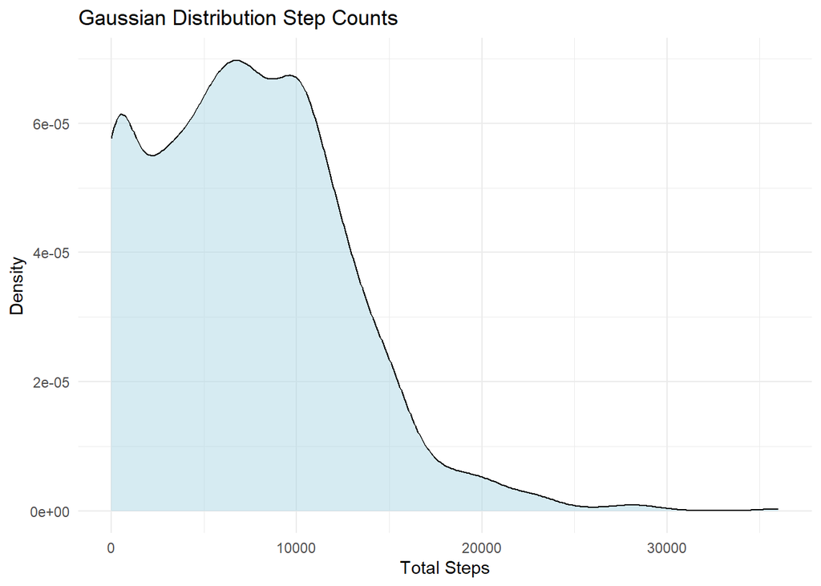

```r
ggplot(dailyActivity, aes(x = total_steps)) + geom_density(kernel = "gaussian", fill = "lightblue", alpha = 0.5) + labs(title = "Gaussian Distribution Step Counts", x = "Total Steps", y = "Density") + theme_minimal()
```

## Correlation Between Variables

Trying to connect with the Sleep dataframe, a relationship was sought between Hourly Calories and the amount of rest people carried out.

```r
dailySleep <- minuteSleep %>%
  mutate(date = as.Date(date)) %>%
  group_by(id, date) %>%
  summarise(total_minutes_slept = sum(value, na.rm = TRUE)) %>%
  ungroup()
```

[output not shown]

```r
dailyCal <- hourlyCalories %>%
  mutate(activity_hour = as.Date(activity_hour)) %>%
  rename(date = activity_hour) %>%
  group_by(id, date) %>%
  summarise(calories = sum(calories, na.rm = TRUE)) %>%
  ungroup()
```

[output not shown]

```r
dailySleepCal <- dailySleep %>%
  inner_join(dailyCal, by = c("id", "date")) %>%
  arrange(date)
cor(dailySleepCal$calories, dailySleepCal$total_minutes_slept)
```

```
## [1] -0.1557065
```

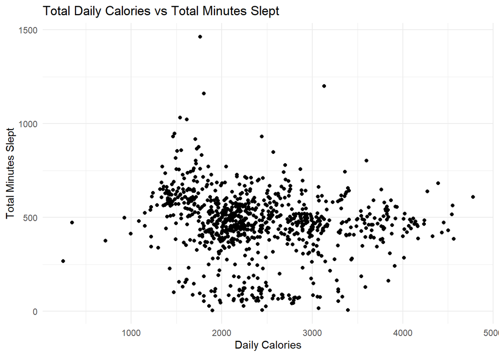

```r
ggplot(dailySleepCal, aes(x=calories, y = total_minutes_slept)) + geom_point() + theme_minimal() + labs(title = "Total Daily Calories vs Total Minutes Slept", x = "Daily Calories", y = "Total Minutes Slept")
```

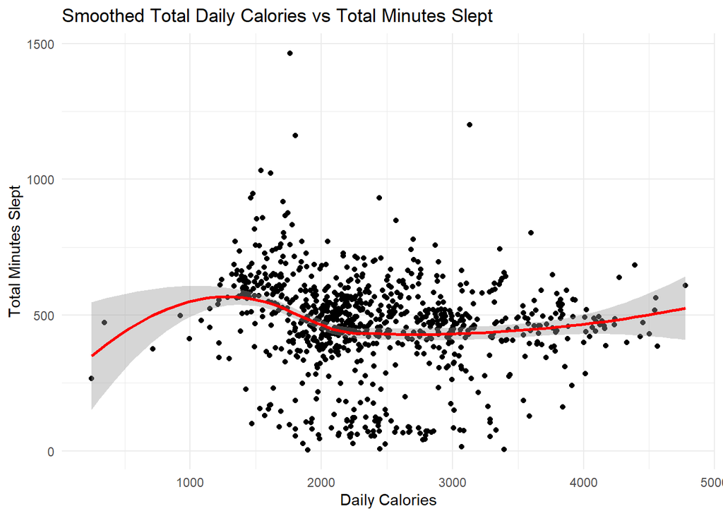

```r
ggplot(dailySleepCal, aes(x= calories, y=total_minutes_slept)) + geom_jitter() + geom_smooth(color = "red")+ labs(title = "Smoothed Total Daily Calories vs Total Minutes Slept", x = "Daily Calories", y = "Total Minutes Slept") + theme_minimal()
```

Initially, as daily calorie consumption increases, total minutes slept increase slightly. Then, the trend flattens and slightly decreases before increasing again at higher calorie intakes. Again, the trend is expected to be a bit steeper, but the sample size, again, was too small. Unfortunately, the cor() function yields a -0.15, so the relationship between daily calorie consumption and total minutes slept appears to be very weak. Seeking a different group of variables to seek a relationship between, the minuteMET (metabolic equivalent) and minuteSleep sets were chosen.

```r
dailyMET <- minuteMET %>%
  mutate(activity_minute = as.Date(activity_minute)) %>%
  rename(date = activity_minute) %>%
  group_by(id, date) %>%
  summarise(me_ts= sum(me_ts, na.rm = TRUE)) %>%
  ungroup()
```

[output not shown]

```r
dailySleepMET <- dailySleep %>%
  inner_join(dailyMET, by = c("id", "date")) %>%
  arrange(date)
cor(dailySleepMET$me_ts, dailySleepMET$total_minutes_slept)
```

```
## [1] -0.0980679
```

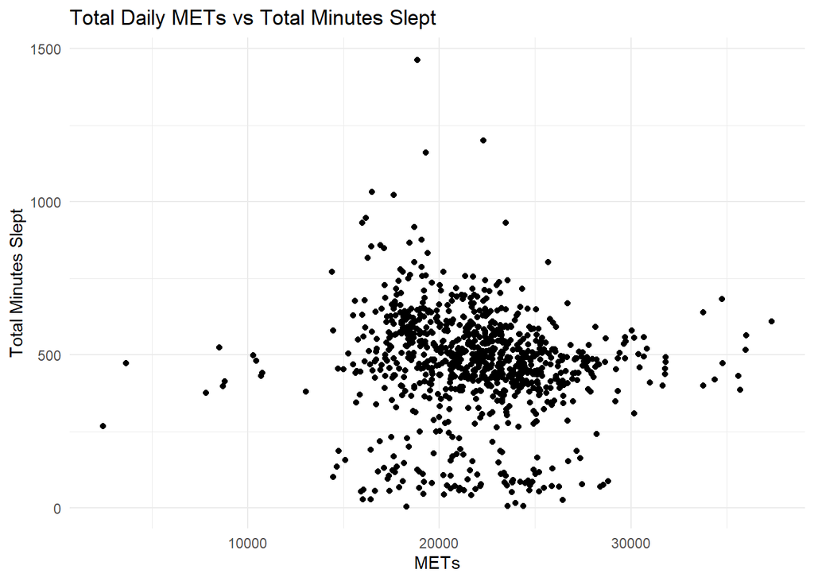

```r
ggplot(dailySleepMET, aes(x=me_ts, y = total_minutes_slept)) + geom_point() + theme_minimal() + labs(title = "Total Daily METs vs Total Minutes Slept", x = "METs", y = "Total Minutes Slept")
```

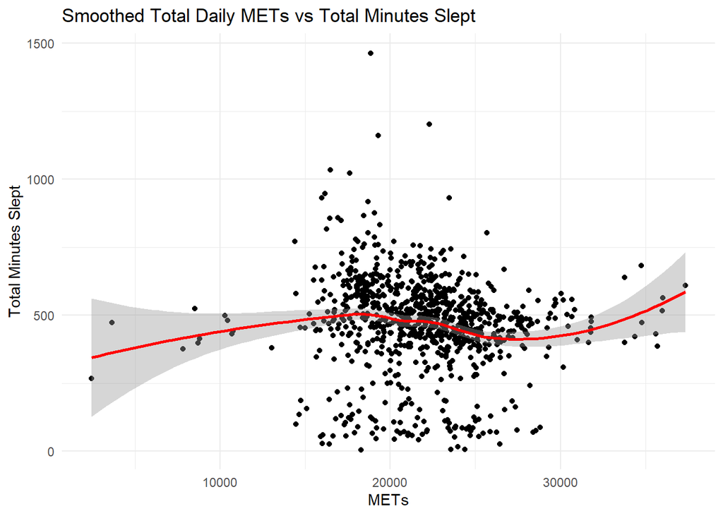

```r
ggplot(dailySleepMET, aes(x= me_ts, y=total_minutes_slept)) + geom_jitter() + geom_smooth(color = "red")+ labs(title = "Smoothed Total Daily METs vs Total Minutes Slept", x = "METs", y = "Total Minutes Slept") + theme_minimal()
```

Unfortunately, once again the correlation coefficient was quite weak (-0.09). Therefore, the variable pair <steps, sleep> was chosen.

```r
dailySteps <- hourlySteps %>%
  mutate(activity_hour = as.Date(activity_hour)) %>%
  rename(date = activity_hour) %>%
  group_by(id, date) %>%
  summarise(step_total= sum(step_total, na.rm = TRUE)) %>%
  ungroup()
```

[output not shown]

```r
dailySleepSteps <- dailySleep %>%
  inner_join(dailySteps, by = c("id", "date")) %>%
  arrange(date)
cor(dailySleepSteps$step_total, dailySleepSteps$total_minutes_slept)
```

```
## [1] -0.09264392
```

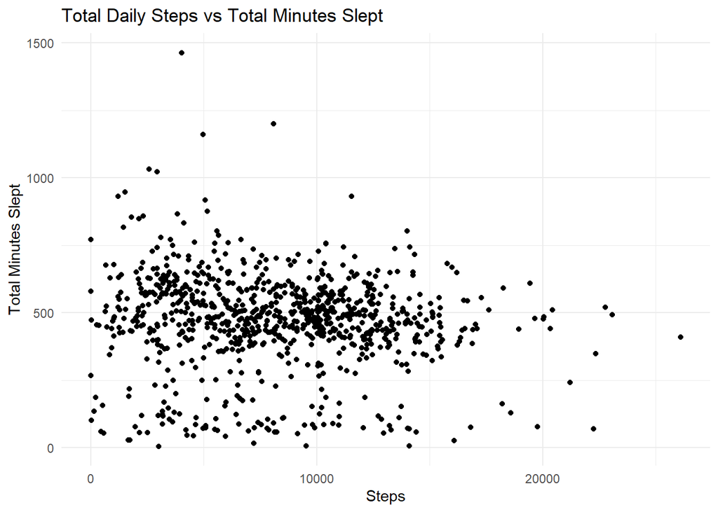

```r
ggplot(dailySleepSteps, aes(x=step_total, y = total_minutes_slept)) + geom_point() + theme_minimal() + labs(title = "Total Daily Steps vs Total Minutes Slept", x = "Steps", y = "Total Minutes Slept")
```

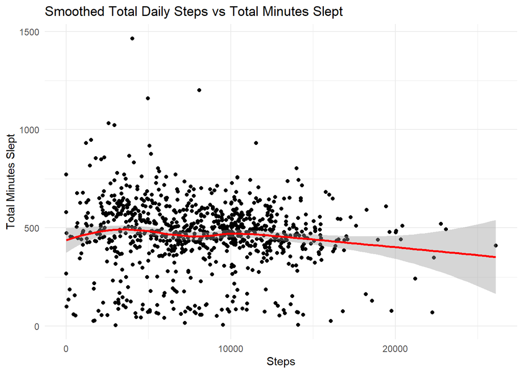

```r
ggplot(dailySleepSteps, aes(x= step_total, y=total_minutes_slept)) + geom_jitter() + geom_smooth(color = "red")+ labs(title = "Smoothed Total Daily Steps vs Total Minutes Slept", x = "Steps", y = "Total Minutes Slept") + theme_minimal()
```

Again, the correlation coefficient was very weak (-0.09). As a last attempt, the distance logged was tried to be matched with the sleep set.

```r
dailyDistance <- dailyActivity %>%
  mutate(activity_date = as.Date(activity_date)) %>%
  rename(date = activity_date) %>%
  group_by(id, date) %>%
  summarise(total_distance= sum(total_distance, na.rm = TRUE)) %>%
  ungroup()
```

[output not shown]

```r
dailySleepDistance <- dailySleep %>%
  inner_join(dailyDistance, by = c("id", "date")) %>%
  arrange(date)
cor(dailySleepDistance$total_distance, dailySleepDistance$total_minutes_slept)
```

```
## [1] -0.1136677
```

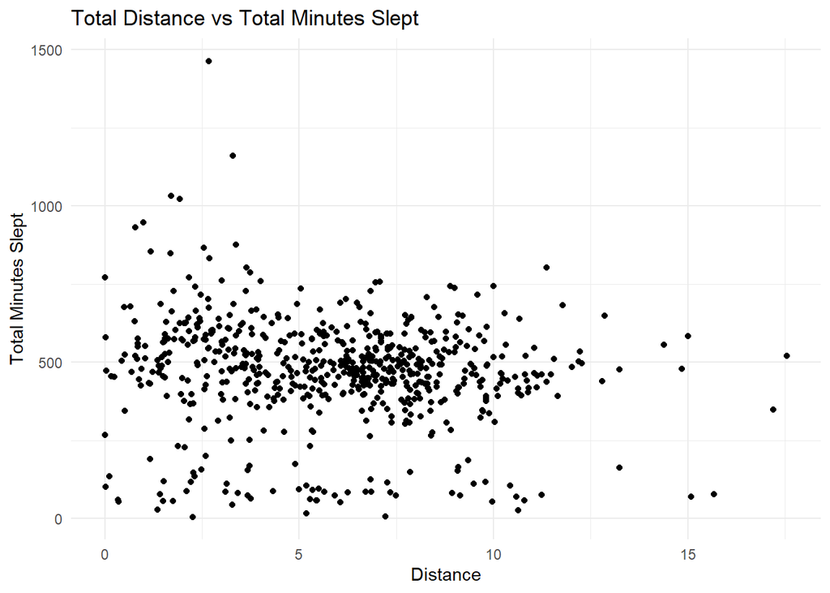

```r
ggplot(dailySleepDistance, aes(x=total_distance, y = total_minutes_slept)) + geom_point() + theme_minimal() + labs(title = "Total Distance vs Total Minutes Slept", x = "Distance", y = "Total Minutes Slept")
```

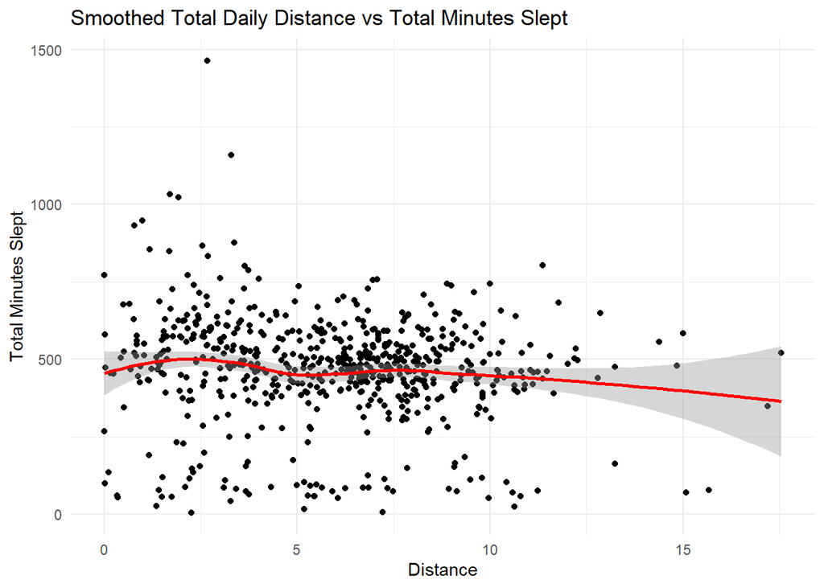

```r
ggplot(dailySleepDistance, aes(x= total_distance, y=total_minutes_slept)) + geom_jitter() + geom_smooth(color = "red")+ labs(title = "Smoothed Total Daily Distance vs Total Minutes Slept", x = "Distance", y = "Total Minutes Slept") + theme_minimal()
```

Once again, the correlation turned out weak (-0.11). As an inference, there must be an external factor influencing what would otherwise be an intuitive relationship between variables. Also, the sleep tracker was not consistently used, so that could be a reason as to why data doesn’t show a connection as strong as one would think. Also, most people only have a set amount of time available for sleeping due to other day-to-day activities, which greatly influences and limits the behavior of data independently of other variables that could or could not affect them.

Turning towards other datasets in order to find a pair of variables that actively show correlations, the attempt was made with Calories and Steps.

```r
dailyCalSteps <- dailyCal %>%
  inner_join(dailySteps, by = c("id","date")) %>%
  arrange(date)
cor(dailyCalSteps$step_total, dailyCalSteps$calories)
```

```
## [1] 0.6211717
```

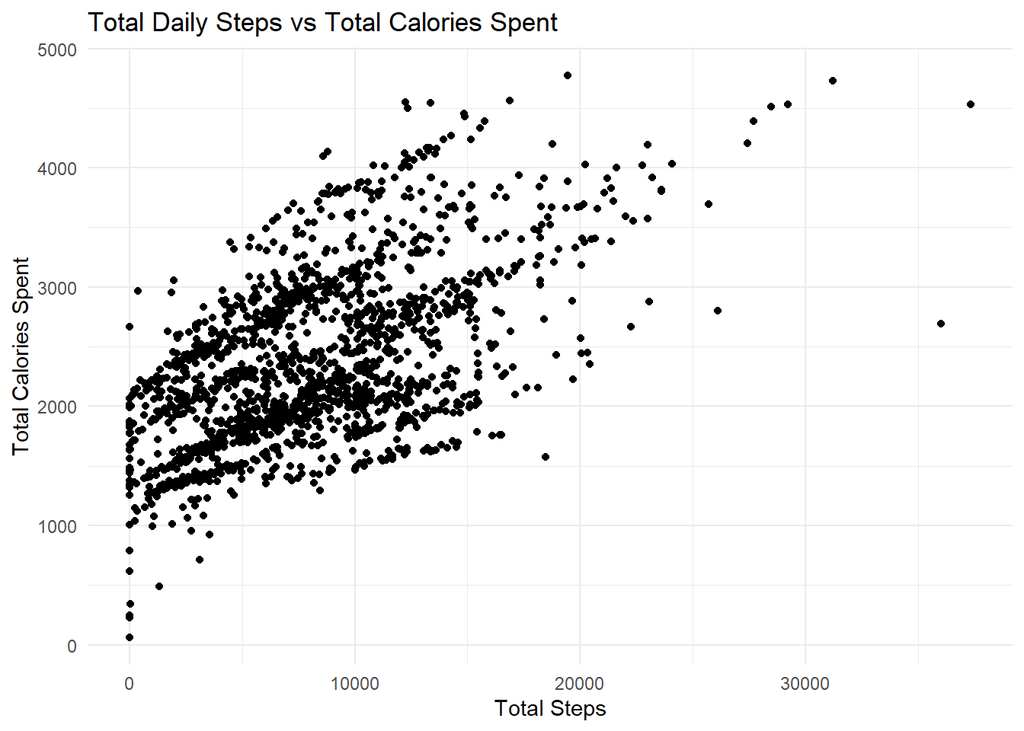

```r
ggplot(dailyCalSteps, aes(x=step_total, y = calories)) + geom_point() + theme_minimal() + labs(title = "Total Daily Steps vs Total Calories Spent", x = "Total Steps", y = "Total Calories Spent")
```

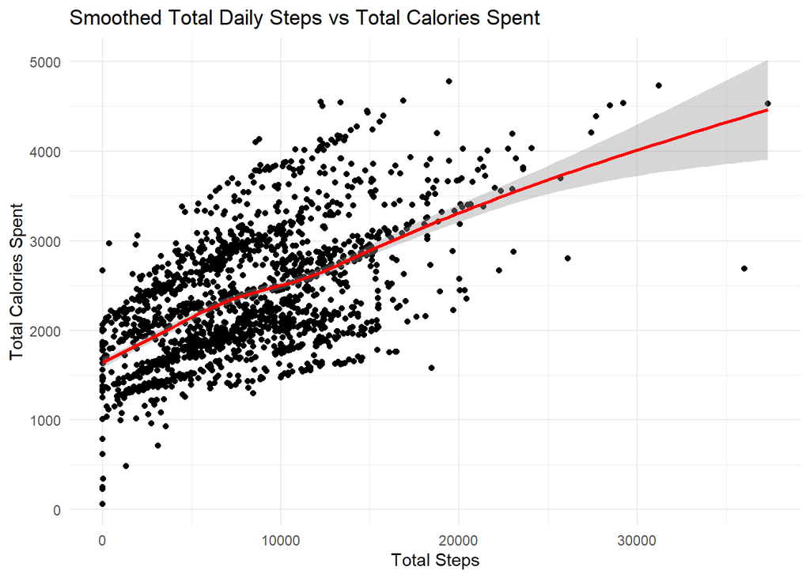

```r
ggplot(dailyCalSteps, aes(x= step_total, y=calories)) + geom_jitter() + geom_smooth(color = "red")+ labs(title = "Smoothed Total Daily Steps vs Total Calories Spent", x = "Total Steps", y = "Total Calories Spent") + theme_minimal()
```

There is a clear positive correlation between total daily steps and total calories spent (0.62, which could be stronger but its a start). More steps generally lead to higher calorie expenditure. The variability in calories spent for a given number of steps, especially at lower step counts, suggests other influencing factors on calorie expenditure, like age, gender, geographical environment, nourishment, particular conditions, etc.

## Consistency in Use of Smart-Device

Moving on, trying to find how consistent the use of the smart device was, the following script was ran:

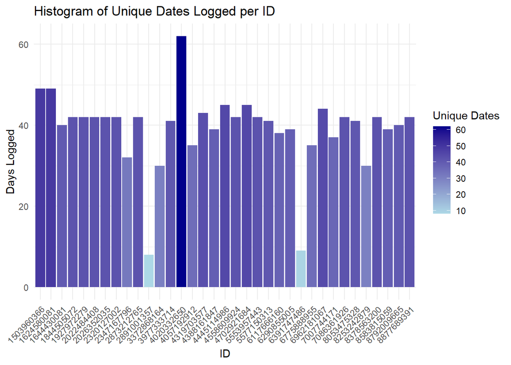

```r
daysUsed <- dailyActivity %>%
  group_by(id) %>%
  summarize(unique_dates = n_distinct(activity_date))
ggplot(daysUsed, aes(x = factor(id), y = unique_dates, fill = unique_dates)) + geom_col() + scale_fill_gradient(low = "lightblue", high = "darkblue") + labs(title = "Histogram of Unique Dates Logged per ID", x = "ID", y = "Days Logged", fill = "Unique Dates") + theme_minimal() + theme(axis.text.x = element_text(angle = 45, hjust = 1))
```

```r
mean(daysUsed$unique_dates)
```

```
## [1] 39.22857
```

```r
n_distinct(dailyActivity$activity_date)
```

```
## [1] 62
```

```r
max(daysUsed$unique_dates)
```

```
## [1] 62
```

```r
min(daysUsed$unique_dates)
```

```
## [1] 8
```

```r
commitmentDates <- mean(daysUsed$unique_dates) / n_distinct(dailyActivity$activity_date) * 100
```

From both the graph and the calculations, its apparent that of the 62 different dates in the cleaned dataframes, on average, each user ID logged data for 39.2 days, or 39. The least amount of days logged was 8, and the maximum was effectively, 62. Therefore, on average, comparing against the total dates, users were 63.27% committed in reporting data with their smart tracker.

# Act Phase

*Analysis Summary*

[output not shown]

*Recommendations* General recommendations regarding tactics and strategies that follow Bellabeat could include:

- Short term: marketing and educational campaigns about the benefits of tracking health and activity, as well as targeting current device features and expanding the existing user base.
- Medium term: product updates and product development focused on new features.
- Long term: expansion into new demographics and markets, as well as collaboration with healthcare providers.

Now, relating insights towards particular recommendations:

1.Focus on Trending Data Features: Bellabeat can capitalize on the growing interest in activity tracking by improving its offerings for basicc daily activity monitoring, such as calorie consumption, steps taken, activity intensity, and METs. These features strongly resonate with sedentary and sedentary-active users, which represent the majority of the demographic in a casual smart-device usage such as FitBit, the source of the data. To appeal to this group, Bellabeat should develop a user-friendly interface that visually presents this data and provides personalized activity goals. Gamification, such as progress badges or challenges, could further motivate users to engage consistently with these features. This would not only improve user satisfaction but also position Bellabeat as a leader in the wellness tracking industry for sedentary users.

2. Enhance Low-Engaged Features: While core features like heart rate monitoring, weight tracking, and sleep data are available, these currently lack high engagement, likely from the complementary demographic opposed to sedentary ones, being more interested in the deeper levels of fitness tracking. To address this, Bellabeat could introduce advanced health-tracking features, such as blood oxygen monitoring and body fat percentage logging, combined with educational tools explaining the benefits of heart rate monitoring, sleep tracking and also weight logging. Partnering with health experts to provide users with actionable insights into their data could also boost interest. Developing a premium subscription tier that includes in-depth analytics or virtual health consultations could further incentivize users to explore these lesser-used features.
3. Promote Sleep Tracking: Sleep tracking presents a growth opportunity for Bellabeat, as moderate engagement suggests room for improvement. The company can differentiate itself by offering personalized insights and actionable recommendations to help users improve sleep quality. Features like guided bedtime routines, sleep coaching, or notifications about optimal sleep windows could increase user interaction and interest in said metric. Bellabeat might also consider integrating a “Sleep Score” feature or product that provides a comprehensive view of users’ sleep health and offers tailored advice for improvement. Enhancing this service would position Bellabeat as a comprehensive health and wellness platform with a diverse product portfolio and opportunities for users.
4. Target Activity-Based Audiences: Bellabeat should consider segmenting its user base by activity levels—sedentary, sedentary-active, and athletic—and tailoring its marketing and product features accordingly. For sedentary users, campaigns could emphasize ease of use and gradual habit building, while for more active users, Bellabeat could highlight advanced tracking features and progress analytics. To attract athletic users, Bellabeat could introduce new capabilities, such as VO2 max tracking or interval training analytics, along with targeted partnerships with sports organizations or fitness clubs, as well as deepening their focus on particular insights in health supervision that is often overlooked, like heart monitoring. By broadening its demographic appeal, Bellabeat could significantly expand its market share.
5. Bellabeat has the opportunity to use insights about the medium-strong correlation between steps and calorie burning to create dynamic, activity-based programs. For example, personalized fitness plans could be generated to help users achieve specific calorie-burning goals, paired with real-time feedback on their progress. A machine learning feature that tracks and predicts calorie expenditure based on activity patterns could also enhance user engagement. Such developments would deepen user trust in the product’s ability to provide actionable insights, reinforcing Bellabeat’s value as a reliable fitness and wellness companion.
6. Consistency is key to extracting value from wellness trackers, and Bellabeat’s data indicates that many users are already committed to tracking daily activity. To encourage even greater consistency, Bellabeat could introduce streak-based rewards or recognition systems that incentivize regular engagement. Monthly progress reports showcasing achievements and offering tips for continued improvement could also be effective. Additionally, integrating reminders for users who miss logging activity could further reduce attrition. By fostering routine usage, Bellabeat ensures long-term user loyalty and maximizes the lifetime value of its customers.

To strengthen its relationship with users and encourage long-term engagement, Bellabeat should explore product bundling and subscription models. For instance, smart trackers could be paired with access to exclusive wellness content, such as guided meditation, fitness routines, or stress management tools. Subscriptions could also include premium features like one-on-one virtual coaching sessions, advanced health insights, or exclusive health challenges. This approach not only provides additional value to users but also generates a steady revenue stream, allowing Bellabeat to continually innovate and expand its offerings.To remain competitive, Bellabeat should consider diversifying its product offerings to serve a broader audience, particularly more active and athletic users who are currently underserved. This could involve developing a new product line tailored to high-performance fitness tracking, featuring metrics such as advanced heart rate variability analysis, workout recovery suggestions, or sport-specific analytics. Additionally, Bellabeat could launch a subscription-based wellness service offering features like personalized coaching, guided workouts, or tailored nutrition plans. By combining innovative hardware with value-added services, Bellabeat could position itself as an all-in-one solution for health and fitness enthusiasts.

By implementing these strategies and introducing new services or products, Bellabeat can broaden its appeal, strengthen user engagement, and establish itself as a leader in the wellness tech industry. Nevertheless, it is paramount to keep analyzing up-to-date and diversified data in order to make the appropriate data-driven decisions.

# References

Psico-Smart Editorial Team. (2024). The Impact of Wearable Technology on Personal Health Monitoring. https://psico-smart.com/en/blogs/blog-the-impact-of-wearable-technology-on-personal-health-monitoring-162704#:~:text=Statistics%20indicate%20that%20as%20of,50%25%20in%20their%20health%20routines.

National Heart, Lung and Blood Institute (2023). Study reveals wearable device trends among US adults. NIH. https://www.nhlbi.nih.gov/news/2023/study-reveals-wearable-device-trends-among-us-adults#:~:text=Almost%20one%20in%20three%20Americans,to%20thousands%20of%20adults%20who

Kaggle, (2024). FitBit Fitness Tracker Data. [dataset]. https://www.kaggle.com/datasets/arashnic/fitbit